# Taller 6: Operaciones geométricas con datos vectoriales

Uso Avanzado de Sistemas de Información Geográfica

Autor/a

Afiliación

Dr. Francisco Zambrano

Escuela de Ingeniería en Medio Ambiente, Universidad Mayor

Fecha de publicación

11 de octubre de 2024

# 1 Objetivo del taller

Trabajar con operaciones geométricas con datos vectoriales en `R` con el paquete `{sf}`

# 2 Paquetes R

Hasta el momento hemos trabajado con los paquetes que vienen inculidos en R base. Ahora empezaremos a trabajar con paquetes adicionales que no vienen instalados por defecto en `R`, por lo que deberá instalarlos. El paquete con el que trabajaremos este taller es `{sf}`, el cual nos permite trabajar con datos de tipo vectoriales.

Para instalar los paquetes debe realizar lo siguiente:

**Código**

```r
# instala los paquetes
install.packages('sf')

# carga los paqutes en el entorno de R y permite utilizar
# las funciones adicionales que contienen

library(sf)
```

# 3 Data

Los datos con los que debe trabajar son:

1- Division comunal: capa con los límites comunales de Chile.

2- Estaciones Chile: capa con la ubicación de las estaciones climáticas en Chile.

Los puede descargar desde [acá](https://drive.google.com/file/d/1vDrP4LL-YvO7Dyk0YuO5ILvEHXAeWon1/view?usp=sharing).

¿Qué debe entregar?

Debeŕa utilizar RStudio para crear un script, en donde resolverá cada uno de los ejercicios. Debe utilizar los comentarios (`#`) para hacer una descripción del ejercicio e incorporar cualquier información que ayude a entender lo realizado. A modo de ejemplo:

**Código**

```r
# Ejercicio 1:
# comentario explicando lo que se hace
{
 Aca va el script que resuelve el ejericio 1

}
```

Debe guardar el script con el nombre “taller6.R”. Los archivos los debe subir en el campus virtual en la sección “Actividades -> Evaluaciones -> Taller 6”

Fecha de entrega

Lunes 14 de octubre hasta las 08:30am

# 4 Ejercicios

1.- Ejercicio 1 (40pts)

- Cargue el archivo vectorial de división comunal de Chile.
- Seleccione las comunas de “La Florida”, “Queilén” y “Molina”
- Realice una simplificación de la geometria con una tolerancia de 200, 500 y 1000 metros y asigne los resultados a nuevos objetos de R.
- Cree un mapa con los resultados.

**Código**

```r
library(sf)
```

**Código**

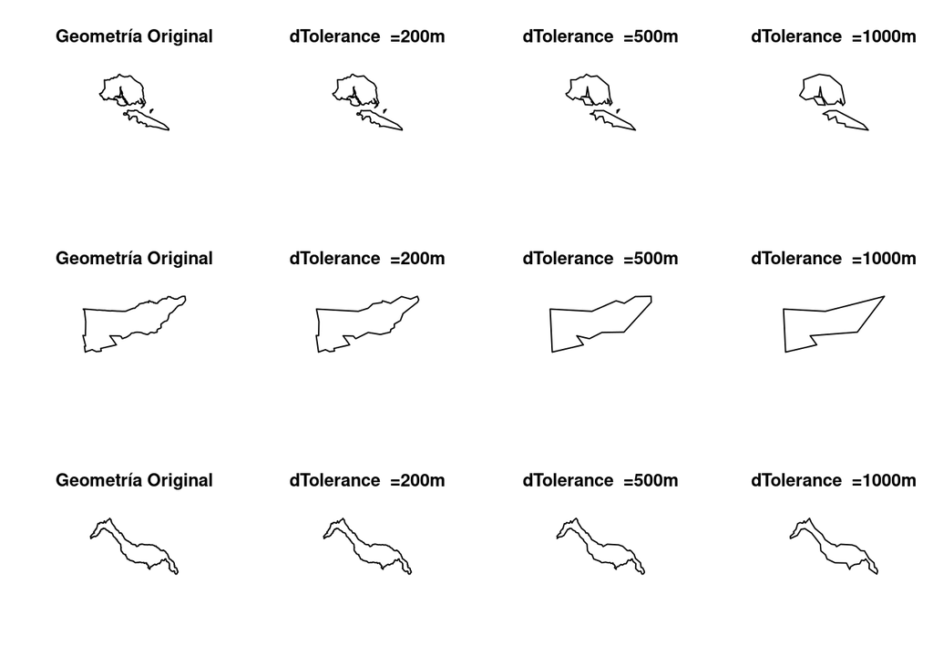

```r
div_comunal <- read_sf('../data/capas/division_comunal')

div_comunal_sub <- subset(div_comunal,NOM_COM %in% c("La Florida", "Queilén", "Molina"))

div_comsub_sim200 <- st_simplify(div_comunal_sub,dTolerance = 200)
div_comsub_sim500 <- st_simplify(div_comunal_sub,dTolerance = 500)
div_comsub_sim1000 <- st_simplify(div_comunal_sub,dTolerance = 1000)

par(mfrow = c(3,4))
plot(div_comunal_sub$geometry[1],main = 'Geometría Original')
plot(div_comsub_sim200$geometry[1],main = 'dTolerance  =200m')
plot(div_comsub_sim500$geometry[1],main = 'dTolerance  =500m')
plot(div_comsub_sim1000$geometry[1],main = 'dTolerance  =1000m')

plot(div_comunal_sub$geometry[2],main = 'Geometría Original')
plot(div_comsub_sim200$geometry[2],main = 'dTolerance  =200m')
plot(div_comsub_sim500$geometry[2],main = 'dTolerance  =500m')
plot(div_comsub_sim1000$geometry[2],main = 'dTolerance  =1000m')

plot(div_comunal_sub$geometry[3],main = 'Geometría Original')
plot(div_comsub_sim200$geometry[3],main = 'dTolerance  =200m')
plot(div_comsub_sim500$geometry[3],main = 'dTolerance  =500m')
plot(div_comsub_sim1000$geometry[3],main = 'dTolerance  =1000m')
```

2.- Ejercicio 2 (40pts)

- Seleccione la región Metropolitana del archivo vectorial de la división comunal de Chile y asigneselo al objeto “rm” .
- Calcule los centroides de cada una de las comunas y guardelo en un objeto llamado “centro_rm”
- Seleccione los centroides de las comunas de la provincia de Santiago
- Cree un mapa en donde se pueda ver los límites de las comunas de la provincia de Santiago y los centroides de cada una.

**Código**

```r
rm <- subset(div_comunal,NOM_REG == "Región Metropolitana de Santiago")

centroides <- st_centroid(rm)
```

**Código**

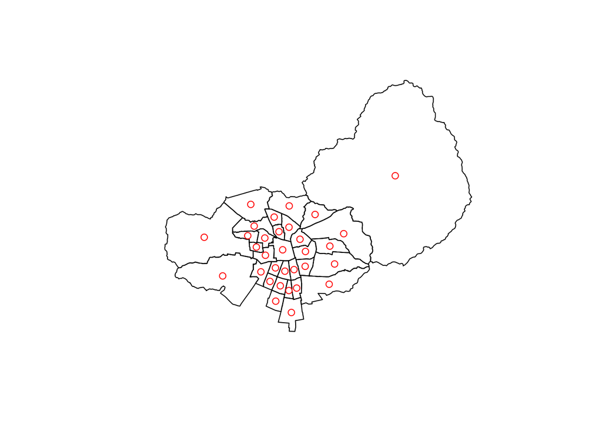

```r
cent_prov_santiago <- centroides[centroides$NOM_PROV == "Santiago",]

prov_sant <- rm[rm$NOM_PROV == 'Santiago',]

plot(st_geometry(prov_sant))
plot(cent_prov_santiago,add = TRUE,col='red')
```

3.- Ejercicio 3 (40pts)

Haga lo mismo que en el ejercicio 2 pero para la región de Los Ríos, pero en el caso de la provincia considere la de Valdivia.

**Código**

```r
lr <- subset(div_comunal,NOM_REG == "Región de Los Ríos")
centroides <- st_centroid(lr)
```

**Código**

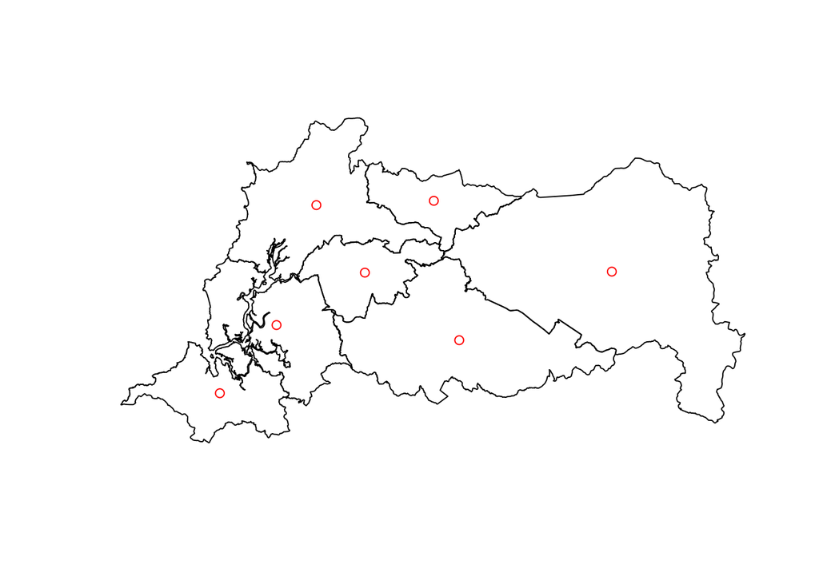

```r
cent_prov_valdivia <- centroides[centroides$NOM_PROV == "Valdivia",]

prov_valdivia <- lr[lr$NOM_PROV == 'Valdivia',]

plot(st_geometry(prov_valdivia))
plot(cent_prov_valdivia,add = TRUE,col='red')
```

4.- Ejercicio 4 (40pts)

- Cargue el archivo vectorial de estaciones de Chile.
- Seleccione las estaciones que se encuentran en la región de O’Higgins.
- Cree un buffer de 500m alrededor de cada estación.
- Seleccione los buffer de las estaciones que pertenecen a la institución INIA.

**Código**

```r
estaciones <- read_sf('../data/capas/estaciones_chile')

reg_ohg <- subset(div_comunal,NOM_REG == "Región del Libertador Bernardo O'Higgins")

reg_ohg_geo <- st_transform(reg_ohg,st_crs(estaciones))
estas_ohg <- st_intersection(estaciones,reg_ohg_geo)
```

**Código**

```r
estas_buffer <- st_buffer(estas_ohg,500)

estas_buffer_inia <- subset(estas_buffer,institucio == 'INIA')

plot(estas_buffer_inia$geometry,col='red')
```

[output not shown]